# From Data to Insight : Uncovering Hidden Wellness Patterns in the Workplace

# K-Means Clustering

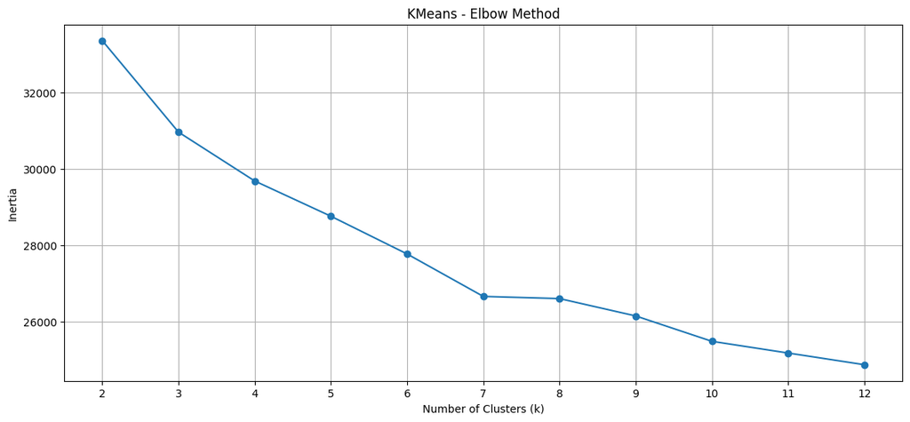

```python
max_k = 12
inertia = []
k_values = range(2, max_k + 1)

for k in k_values:
    kmeans = KMeans(n_clusters=k, random_state=42, max_iter=1000)
    kmeans.fit_predict(X_scaled_df)
    inertia.append(kmeans.inertia_)

plt.figure(figsize=(14, 6))  # fixed

plt.plot(k_values, inertia, marker='o')  # added line plot
plt.title('KMeans - Elbow Method')
plt.xlabel('Number of Clusters (k)')
plt.ylabel('Inertia')
plt.xticks(k_values)
plt.grid(True)

plt.show()
```

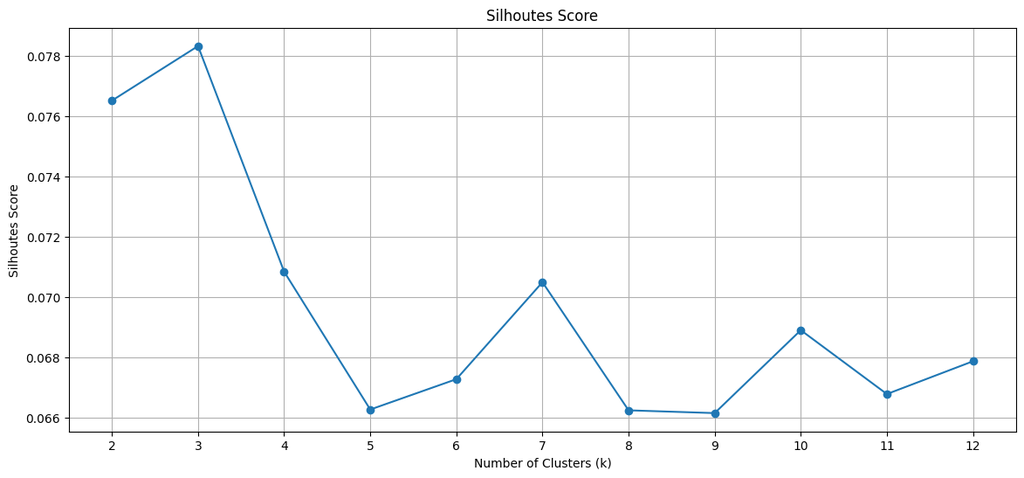

```python
max_k = 12
inertia = []
silhouette_scores = []
k_values = range(2, max_k + 1)

for k in k_values:
    kmeans = KMeans(n_clusters=k, random_state=42, max_iter=1000)
    cluster_labels  = kmeans.fit_predict(X_scaled_df)
    sil_score = silhouette_score(X_scaled_df,cluster_labels)

    silhouette_scores.append(sil_score)
    inertia.append(kmeans.inertia_)

plt.figure(figsize=(14, 6))  # fixed

plt.plot(k_values, silhouette_scores, marker='o')  # added line plot
plt.title('Silhoutes Score')
plt.xlabel('Number of Clusters (k)')
plt.ylabel('Silhoutes Score')
plt.xticks(k_values)
plt.grid(True)

plt.show()
```

Highest silhouette score at k = 3 (~0.078).

Next stable, moderate values around k = 7 and k = 12.

Scores are low overall (~0.06 - 0.078), indicating:

Data is not strongly clusterable in well-separated blobs.

Clusters may overlap, but can still segment for HR actions.

```python
df_model.head()
```

|  | Current Employee Rating | Engagement Score | Satisfaction Score | Work-Life Balance Score | EmployeeStatus_Encoded | TrainingOutcome_Encoded | PayZone_Encoded | PerformanceScore_Encoded | JobFunctionGroup_Encoded | EmployeeType_Encoded | TenureYears | Age |
| --- | --- | --- | --- | --- | --- | --- | --- | --- | --- | --- | --- | --- |
| 0 | 4 | 1 | 2 | 3 | 0 | 1 | 2 | 2 | 3 | 0 | 5 | 55 |
| 1 | 3 | 2 | 1 | 5 | 0 | 0 | 0 | 2 | 1 | 0 | 2 | 59 |
| 2 | 4 | 1 | 2 | 1 | 0 | 1 | 1 | 2 | 5 | 2 | 6 | 33 |
| 3 | 2 | 5 | 5 | 4 | 0 | 2 | 0 | 2 | 5 | 0 | 4 | 27 |
| 4 | 3 | 2 | 5 | 3 | 0 | 1 | 0 | 2 | 1 | 0 | 6 | 55 |

Run KMeans with k = 3, k = 4, and k = 7.

Analyze cluster distributions and centroids.

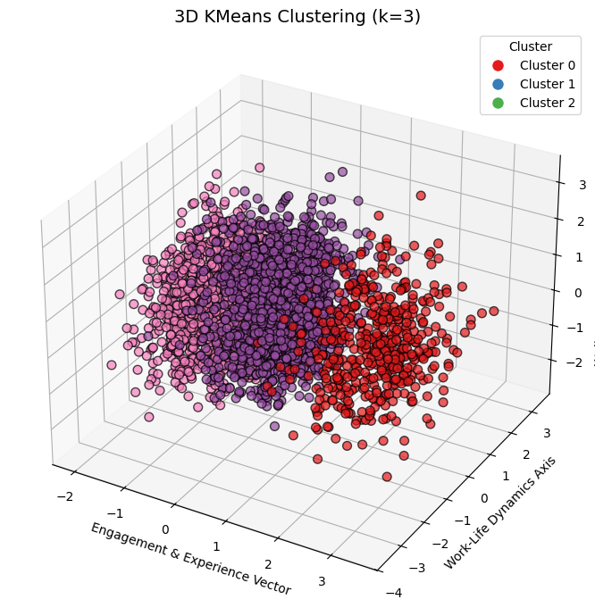

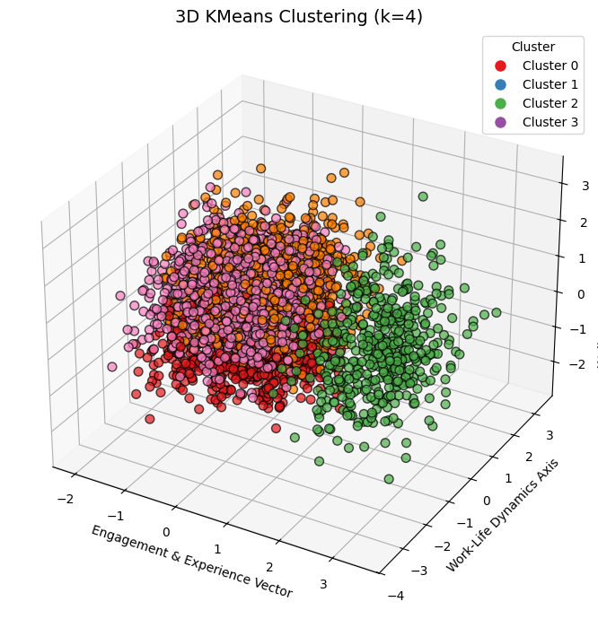

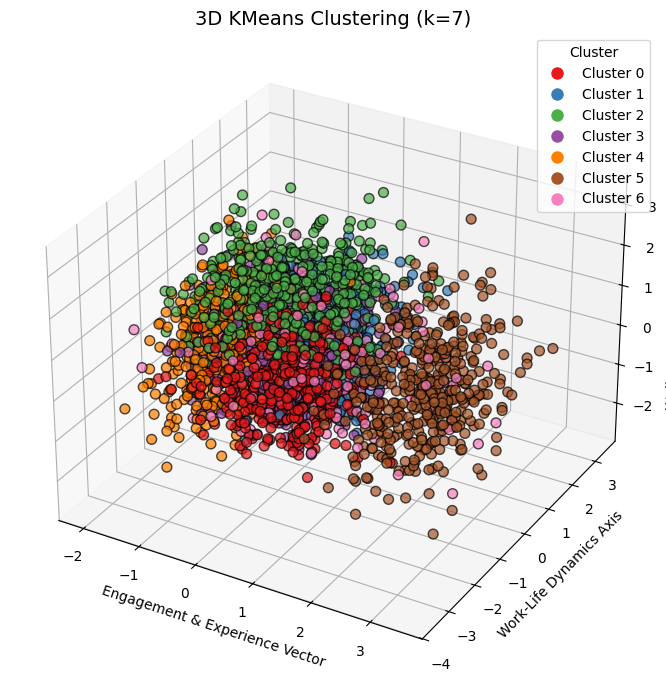

|  | k | Inertia | Silhouette |
| --- | --- | --- | --- |
| 0 | 3 | 30964.450640 | 0.078338 |
| 1 | 4 | 29685.007605 | 0.070851 |
| 2 | 7 | 26661.885836 | 0.070502 |

```python
results = []

k_values = [3, 4, 7]
high_contrast_colors = ListedColormap(['#e41a1c', '#377eb8', '#4daf4a', '#984ea3', '#ff7f00', '#a65628', '#f781bf'])

pca = PCA(n_components=3)
X_pca_3d = pca.fit_transform(X_scaled)

for k in k_values:
    kmeans = KMeans(n_clusters=k, random_state=42)
    cluster_labels = kmeans.fit_predict(X_scaled)

    inertia = kmeans.inertia_
    silhouette = silhouette_score(X_scaled, cluster_labels)

    results.append({'k': k, 'Inertia': inertia, 'Silhouette': silhouette})

    # 3D scatter plot
    fig = plt.figure(figsize=(10, 7))
    ax = fig.add_subplot(111, projection='3d')
    scatter = ax.scatter(
        X_pca_3d[:, 0], X_pca_3d[:, 1], X_pca_3d[:, 2],
        c=cluster_labels, cmap=high_contrast_colors, s=50, edgecolors='k', alpha=0.7
    )

    ax.set_xlabel("Engagement & Experience Vector")
    ax.set_ylabel("Work-Life Dynamics Axis")
    ax.set_zlabel("Wellness Sentiment Dimension")
    ax.set_title(f"3D KMeans Clustering (k={k})", fontsize=14)

    # Legend
    legend_elements = [
        Line2D([0], [0], marker='o', color='w', label=f'Cluster {i}',
               markerfacecolor=high_contrast_colors.colors[i % len(high_contrast_colors.colors)],
               markersize=10) for i in range(k)
    ]
    ax.legend(handles=legend_elements, title="Cluster", loc='best')

    plt.tight_layout()
    plt.show()

# Display comparison table
results_df = pd.DataFrame(results)
display(results_df)
```

Inertia Trend:

k=3 → k=4:

k=4 → k=7:

Inertia consistently decreases with higher k, as expected.

The drop is significant when moving from 4 to 7, indicating that k=7 captures additional structure.

Silhouette Score

k=3: 0.0784 (highest)

k=4: 0.0708 (drops)

k=7: 0.0703 (slightly lower than k=4)

Highest silhouette score at k=3, indicating the clearest cluster separation. The drop from 0.0784 → 0.0708 (~9.7% drop) at k=4 is notable. From k=4 → k=7, the silhouette remains almost the same (~0.0708 → 0.0703).

```
Silhouette Score (Agglomerative, k=3): 0.13652
Cluster 0: 2424 employees
Cluster 1: 423 employees
Cluster 2: 153 employees
```

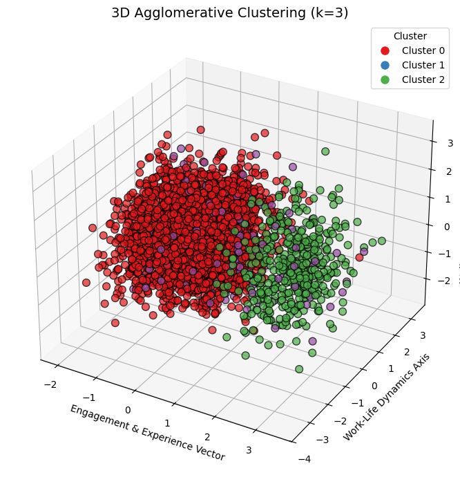

```python
# now try  Hierarchical Clustering (Agglomerative)
agglo = AgglomerativeClustering(n_clusters=3)
agglo_labels = agglo.fit_predict(X_scaled)

silhouette_agglo = silhouette_score(X_scaled, agglo_labels)
print(f"Silhouette Score (Agglomerative, k=3): {silhouette_agglo:.5f}")

import numpy as np
unique, counts = np.unique(agglo_labels, return_counts=True)
for u, c in zip(unique, counts):
    print(f"Cluster {u}: {c} employees")

high_contrast_colors = ListedColormap(['#e41a1c', '#377eb8', '#4daf4a', '#984ea3'])

fig = plt.figure(figsize=(10, 7))
ax = fig.add_subplot(111, projection='3d')

scatter = ax.scatter(
    X_pca_3d[:, 0], X_pca_3d[:, 1], X_pca_3d[:, 2],
    c=agglo_labels, cmap=high_contrast_colors, s=60, edgecolors='k', alpha=0.7
)

ax.set_title("3D Agglomerative Clustering (k=3)", fontsize=14)
ax.set_xlabel("Engagement & Experience Vector")
ax.set_ylabel("Work-Life Dynamics Axis")
ax.set_zlabel("Wellness Sentiment Dimension")


legend_elements = [
    Line2D([0], [0], marker='o', color='w', label=f'Cluster {i}',
           markerfacecolor=high_contrast_colors.colors[i % len(high_contrast_colors.colors)],
           markersize=10) for i in range(3)
]
ax.legend(handles=legend_elements, title="Cluster", loc='best')

plt.tight_layout()
plt.show()

df_model['Cluster_Agglo_k3'] = agglo_labels
```

```
Silhouette Score (GMM, k=3): 0.07372
Cluster 0: 542 employees
Cluster 1: 1942 employees
Cluster 2: 516 employees
```

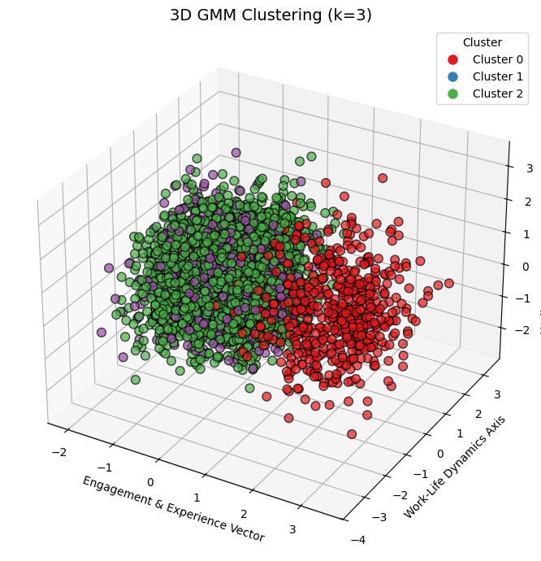

```python
#  Gaussian Mixture Models (GMM)
gmm = GaussianMixture(n_components=3, random_state=42)
gmm_labels = gmm.fit_predict(X_scaled)

silhouette_gmm = silhouette_score(X_scaled, gmm_labels)
print(f"Silhouette Score (GMM, k=3): {silhouette_gmm:.5f}")

unique, counts = np.unique(gmm_labels, return_counts=True)
for u, c in zip(unique, counts):
    print(f"Cluster {u}: {c} employees")

high_contrast_colors = ListedColormap(['#e41a1c', '#377eb8', '#4daf4a', '#984ea3'])

fig = plt.figure(figsize=(10, 7))
ax = fig.add_subplot(111, projection='3d')

scatter = ax.scatter(
    X_pca_3d[:, 0], X_pca_3d[:, 1], X_pca_3d[:, 2],
    c=gmm_labels, cmap=high_contrast_colors, s=60, edgecolors='k', alpha=0.7
)

ax.set_title("3D GMM Clustering (k=3)", fontsize=14)
ax.set_xlabel("Engagement & Experience Vector")
ax.set_ylabel("Work-Life Dynamics Axis")
ax.set_zlabel("Wellness Sentiment Dimension")

legend_elements = [
    Line2D([0], [0], marker='o', color='w', label=f'Cluster {i}',
           markerfacecolor=high_contrast_colors.colors[i % len(high_contrast_colors.colors)],
           markersize=10) for i in range(3)
]
ax.legend(handles=legend_elements, title="Cluster", loc='best')

plt.tight_layout()
plt.show()

# Store for further HR profiling
df_model['Cluster_GMM_k3'] = gmm_labels
```

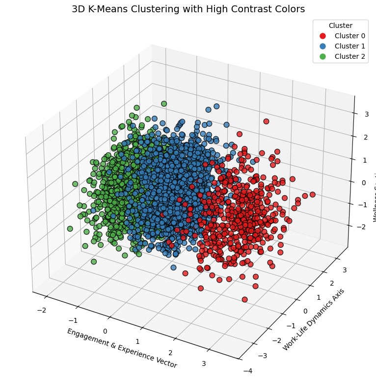

```python
pca = PCA(n_components=3)
X_pca_3d = pca.fit_transform(X_scaled)

kmeans = KMeans(n_clusters=3, random_state=42)
df_model['Cluster'] = kmeans.fit_predict(X_scaled)

high_contrast_colors = ListedColormap(['#e41a1c', '#377eb8', '#4daf4a'])  # red, blue, green, purple

fig = plt.figure(figsize=(12, 8))
ax = fig.add_subplot(111, projection='3d')

scatter = ax.scatter(
    X_pca_3d[:, 0], X_pca_3d[:, 1], X_pca_3d[:, 2],
    c=df_model['Cluster'], cmap=high_contrast_colors, s=60, edgecolors='k', alpha=0.8
)

ax.set_title("3D K-Means Clustering with High Contrast Colors", fontsize=14)
ax.set_xlabel("Engagement & Experience Vector")
ax.set_ylabel("Work-Life Dynamics Axis")
ax.set_zlabel("Wellness Sentiment Dimension")

# Manually create legend
from matplotlib.lines import Line2D
legend_elements = [
    Line2D([0], [0], marker='o', color='w', label='Cluster 0', markerfacecolor='#e41a1c', markersize=10),
    Line2D([0], [0], marker='o', color='w', label='Cluster 1', markerfacecolor='#377eb8', markersize=10),
    Line2D([0], [0], marker='o', color='w', label='Cluster 2', markerfacecolor='#4daf4a', markersize=10),
]
ax.legend(handles=legend_elements, title="Cluster", loc='best')

plt.tight_layout()
plt.show()
```

```python
cluster_column = 'Cluster'
numeric_features = [
    'Current Employee Rating', 'Engagement Score', 'Satisfaction Score', 'Work-Life Balance Score',
    'TenureYears', 'Age'
]
cluster_means = df_model.groupby(cluster_column)[numeric_features].mean().round(2)
cluster_sizes = df_model[cluster_column].value_counts().sort_index()


categorical_features = [
    'PerformanceScore_Encoded', 'JobFunctionGroup_Encoded', 'EmployeeType_Encoded'
]

for cat_feature in categorical_features:
    print(f"\n Distribution of {cat_feature} by Cluster:")
    crosstab = pd.crosstab(df_model[cluster_column], df_model[cat_feature], normalize='index') * 100
    crosstab = crosstab.round(1)
    print(crosstab)
```

```
 Distribution of PerformanceScore_Encoded by Cluster:
PerformanceScore_Encoded    0    1     2     3
Cluster
0                         5.3  5.7  78.9  10.1
1                         2.4  5.8  79.3  12.6
2                         3.1  6.1  77.9  12.9

 Distribution of JobFunctionGroup_Encoded by Cluster:
JobFunctionGroup_Encoded     0     1     2     3     4    5    6
Cluster
0                         30.0  21.4  12.3  14.8   9.3  7.8  4.4
1                         23.2  19.5  14.8  13.7  12.3  9.1  7.4
2                         33.2  24.7  14.1  10.8   8.0  6.1  3.1

 Distribution of EmployeeType_Encoded by Cluster:
EmployeeType_Encoded     0     1     2
Cluster
0                     31.3  32.3  36.4
1                     33.6  32.2  34.1
2                     34.5  31.1  34.4
```

```python
print(" Cluster Sizes:")
print(cluster_sizes)
```

```
 Cluster Sizes:
Cluster
0     473
1    1394
2    1133
Name: count, dtype: int64
```

```python
print(cluster_means)
```

```
         Current Employee Rating  Engagement Score  Satisfaction Score  \
Cluster
0                           3.04              2.89                3.08
1                           2.95              2.90                3.03
2                           2.97              3.00                2.98

         Work-Life Balance Score  TenureYears    Age
Cluster
0                           2.89         0.98  53.66
1                           2.93         1.16  52.92
2                           3.10         4.51  53.90
```

✅ Cluster 0 (15.8%): Shortest tenure, slightly lower engagement/WLB, high satisfaction → Newer employees; focus on onboarding, early retention, and engagement strategies

```python
df_model.columns
```

```
Index(['Current Employee Rating', 'Engagement Score', 'Satisfaction Score',
       'Work-Life Balance Score', 'EmployeeStatus_Encoded',
       'TrainingOutcome_Encoded', 'PayZone_Encoded',
       'PerformanceScore_Encoded', 'JobFunctionGroup_Encoded',
       'EmployeeType_Encoded', 'TenureYears', 'Age', 'Cluster_Agglo_k3',
       'Cluster_GMM_k3', 'Cluster'],
      dtype='object')
```

```python
performance_cluster_name_map = {
    0: "High Rated, Satisfied",
    1: "Moderate Performers",
    2: "Highly Engaged, Balanced"
}

df_model['Cluster_Label'] = df_model['Cluster'].map(performance_cluster_name_map)

print(df_model['Cluster_Label'].value_counts())
```

```
Cluster_Label
Moderate Performers         1394
Highly Engaged, Balanced    1133
High Rated, Satisfied        473
Name: count, dtype: int64
```

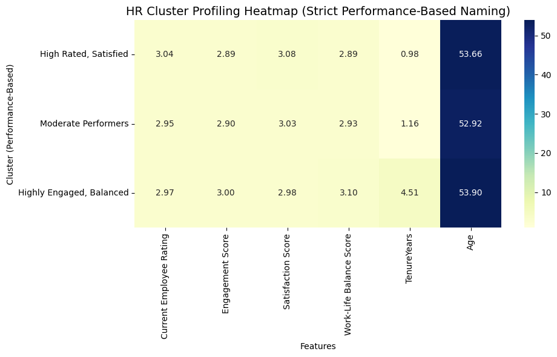

```python
features_for_heatmap = [
    'Current Employee Rating', 'Engagement Score', 'Satisfaction Score',
    'Work-Life Balance Score', 'TenureYears', 'Age'
]
heatmap_data = df_model.groupby('Cluster_Label')[features_for_heatmap].mean().round(2)

heatmap_data = heatmap_data.loc[
    ["High Rated, Satisfied", "Moderate Performers", "Highly Engaged, Balanced"]
]

plt.figure(figsize=(10, 6))
sns.heatmap(heatmap_data, annot=True, fmt=".2f", cmap="YlGnBu", cbar=True)
plt.title("HR Cluster Profiling Heatmap (Strict Performance-Based Naming)", fontsize=14)
plt.xlabel("Features")
plt.ylabel("Cluster (Performance-Based)")
plt.tight_layout()
plt.show()
```

```python
df_model['Employee ID'] = df['Employee ID'].values
```

```python
columns_for_export = [
    'Employee ID', 'Current Employee Rating', 'Engagement Score', 'Satisfaction Score',
    'Work-Life Balance Score', 'EmployeeStatus_Encoded', 'TrainingOutcome_Encoded',
    'PayZone_Encoded', 'PerformanceScore_Encoded', 'JobFunctionGroup_Encoded',
    'EmployeeType_Encoded', 'TenureYears', 'Age',
    'Cluster', 'Cluster_Label'
]

# Create final export DataFrame
export_df = df_model[columns_for_export]

export_df.to_csv("HR_Clustering_PerformanceBased_KMeans_k3_PowerBI.csv", index=False)

print("✅ file saved successfully")
```

```
✅ file saved successfully
```